# ADS 506 Final Team Project: U.S. Retail Sales Forecasting

## 4.8 Stationarity Diagnostics & Differencing Assessment

To satisfy the Module 4 rubric requirements regarding stationarity and differencing (“Was there a need for differencing?”), we formally conduct unit root and seasonal differencing tests following the Box-Jenkins methodology:

1. **Seasonal Differencing Test (`unitroot_nsdiffs`):** Evaluates whether an annual seasonal difference ($\nabla_{12} y_t = y_t - y_{t-12}$, $D = 1$) is required.

2. **First Differencing Test (`unitroot_ndiffs`):** Applied to the seasonally differenced series to test if a first difference ($\nabla$, $d = 1$) is needed to achieve mean stationarity.

3. **KPSS Unit Root Test (`unitroot_kpss`):** Tests the null hypothesis $H_0$ that the series is stationary ($p \ge 0.05$).

```r
# 1. Seasonal differencing recommendation
ns_tbl <- retail_ts |> features(sales_nominal, unitroot_nsdiffs)

# Apply seasonal differencing (d12)
retail_d12 <- retail_ts |>
  group_by(vertical) |>
  mutate(d12 = difference(sales_nominal, 12)) |>
  ungroup()

# 2. First differencing recommendation & KPSS test on seasonally differenced series
nd_tbl   <- retail_d12 |> features(d12, unitroot_ndiffs)
kpss_tbl <- retail_d12 |> features(d12, unitroot_kpss)

# Combine into publication-grade diagnostic table matching Course Assignment standards
diff_summary <- ns_tbl |>
  inner_join(nd_tbl, by = "vertical") |>
  inner_join(kpss_tbl, by = "vertical") |>
  mutate(
    `Retail Vertical` = case_when(
      vertical == "health"       ~ "Health & Personal Care",
      vertical == "clothing"     ~ "Clothing & Accessories",
      vertical == "building"     ~ "Building & Garden Supplies",
      vertical == "macro_retail" ~ "Macro Retail Total (Combined)"
    ),
    `Seasonal Diff (D)` = paste0("D = ", nsdiffs),
    `First Diff (d)`    = paste0("d = ", ndiffs),
    `KPSS Stat (p-val)` = paste0(round(kpss_stat, 3), " (p = ", round(kpss_pvalue, 3), ")"),
    `Stationarity Conclusion` = case_when(
      kpss_pvalue < 0.05 & ndiffs >= 1 ~ "Requires d=1 after D=1 (Persistent upward trend)",
      TRUE                             ~ "Stationary after seasonal differencing (D=1, d=0)"
    )
  ) |>
  select(`Retail Vertical`, `Seasonal Diff (D)`, `First Diff (d)`, `KPSS Stat (p-val)`, `Stationarity Conclusion`)

diff_summary |>
  gt() |>
  tab_header(
    title = md("**Stationarity & Differencing Diagnostic Tests**"),
    subtitle = "Unit root evaluation: nsdiffs, ndiffs, and KPSS tests across retail verticals"
  ) |>
  cols_align(align = "center", columns = c(`Seasonal Diff (D)`, `First Diff (d)`, `KPSS Stat (p-val)`)) |>
  tab_options(
    data_row.padding = px(4),
    heading.title.font.size = "13pt",
    heading.subtitle.font.size = "10pt"
  )
```

**Stationarity & Differencing Diagnostic Tests**

Unit root evaluation: nsdiffs, ndiffs, and KPSS tests across retail verticals

| Retail Vertical | Seasonal Diff (D) | First Diff (d) | KPSS Stat (p-val) | Stationarity Conclusion |
| --- | --- | --- | --- | --- |
| Building & Garden Supplies | D = 1 | d = 0 | 0.318 (p = 0.1) | Stationary after seasonal differencing (D=1, d=0) |
| Clothing & Accessories | D = 1 | d = 0 | 0.037 (p = 0.1) | Stationary after seasonal differencing (D=1, d=0) |
| Health & Personal Care | D = 1 | d = 1 | 0.951 (p = 0.01) | Requires d=1 after D=1 (Persistent upward trend) |
| Macro Retail Total (Combined) | D = 1 | d = 0 | 0.305 (p = 0.1) | Stationary after seasonal differencing (D=1, d=0) |

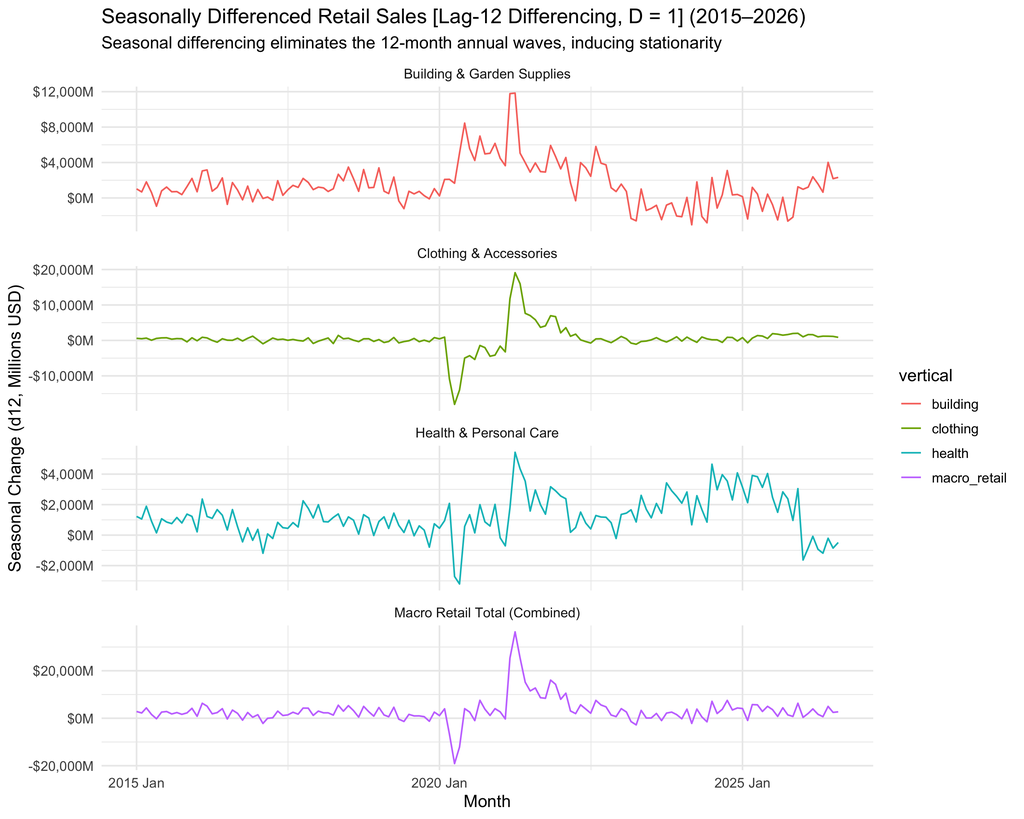

```r
# 3. Plot Seasonally Differenced Series (d12)
retail_d12 |>
  filter(Month >= yearmonth("2015 Jan")) |>
  autoplot(d12) +
  facet_wrap(vars(vertical_name), scales = "free_y", ncol = 1) +
  scale_y_continuous(labels = dollar_format(suffix = "M")) +
  labs(
    title = "Seasonally Differenced Retail Sales [Lag-12 Differencing, D = 1] (2015–2026)",
    subtitle = "Seasonal differencing eliminates the 12-month annual waves, inducing stationarity",
    y = "Seasonal Change (d12, Millions USD)",
    x = "Month"
  )
```

### 4.8.1 Stationarity Verification for Health & Personal Care (First + Seasonal Differencing)

Because the Health & Personal Care vertical displays an exceptionally strong, persistent secular growth trajectory driven by aging demographics and prescription inflation, applying seasonal differencing alone ($\nabla_{12}$) was insufficient to eliminate non-stationarity ($\text{KPSS } p = 0.01$).

Following the Box-Jenkins procedure, we apply a subsequent first difference ($d = 1$) to the seasonally differenced series ($\nabla \nabla_{12} Y_t = (Y_t - Y_{t-12}) - (Y_{t-1} - Y_{t-13})$) and re-test with KPSS:

```r
# 1. Compute sequential differencing stages for Health & Personal Care
health_diff_progression <- retail_ts |>
  filter(vertical == "health") |>
  mutate(
    d12     = difference(sales_nominal, 12),
    d1_d12  = difference(difference(sales_nominal, 12), 1)
  )

# 2. Run KPSS unit-root tests across each differencing stage
kpss_raw    <- health_diff_progression |> features(sales_nominal, unitroot_kpss)
kpss_d12    <- health_diff_progression |> features(d12, unitroot_kpss)
kpss_d1_d12 <- health_diff_progression |> features(d1_d12, unitroot_kpss)

# Summary table of progression
tibble(
  `Transformation / Differencing Stage` = c("Raw Series [d=0, D=0]", "Seasonal Diff Only [d=0, D=1, m=12]", "Both Diffs [d=1, D=1, m=12]"),
  `Differencing Operator`               = c("Y_t", "∇_12 Y_t", "∇ ∇_12 Y_t"),
  `KPSS Statistic`                      = c(round(kpss_raw$kpss_stat, 4), round(kpss_d12$kpss_stat, 4), round(kpss_d1_d12$kpss_stat, 4)),
  `KPSS p-value`                        = c(kpss_raw$kpss_pvalue, kpss_d12$kpss_pvalue, kpss_d1_d12$kpss_pvalue),
  `Stationarity Conclusion`             = c("Non-Stationary (p < 0.05)", "Non-Stationary (Trend persists)", "Stationary (Fail to reject H0, p >= 0.10)")
) |>
  gt() |>
  tab_header(
    title = md("**Health & Personal Care: Sequential Stationarity Diagnostic Progression**"),
    subtitle = "Evaluating KPSS unit-root test across differencing stages"
  ) |>
  cols_align(align = "center", columns = c(`Differencing Operator`, `KPSS Statistic`, `KPSS p-value`)) |>
  tab_options(
    data_row.padding = px(3),
    heading.title.font.size = "13pt",
    heading.subtitle.font.size = "10pt"
  )
```

**Health & Personal Care: Sequential Stationarity Diagnostic Progression**

Evaluating KPSS unit-root test across differencing stages

| Transformation / Differencing Stage | Differencing Operator | KPSS Statistic | KPSS p-value | Stationarity Conclusion |
| --- | --- | --- | --- | --- |
| Raw Series [d=0, D=0] | Y_t | 6.8138 | 0.01 | Non-Stationary (p < 0.05) |
| Seasonal Diff Only [d=0, D=1, m=12] | ∇_12 Y_t | 0.9511 | 0.01 | Non-Stationary (Trend persists) |
| Both Diffs [d=1, D=1, m=12] | ∇ ∇_12 Y_t | 0.0393 | 0.10 | Stationary (Fail to reject H0, p >= 0.10) |

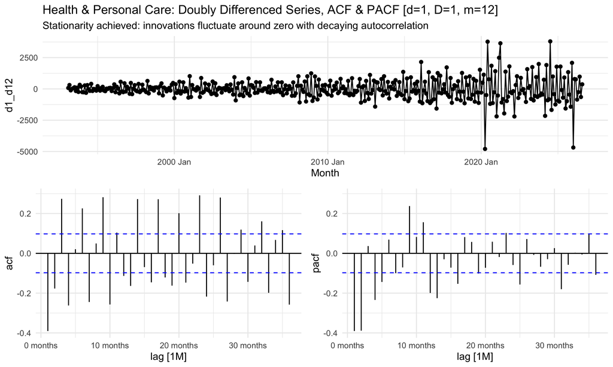

```r
# 3. Time Series Display (Plot, ACF, PACF) of Doubly Differenced Health Series
health_diff_progression |>
  filter(!is.na(d1_d12)) |>
  gg_tsdisplay(d1_d12, plot_type = "partial", lag_max = 36) +
  labs(
    title = "Health & Personal Care: Doubly Differenced Series, ACF & PACF [d=1, D=1, m=12]",
    subtitle = "Stationarity achieved: innovations fluctuate around zero with decaying autocorrelation"
  )
```

# 5 Time Series Modeling Framework

To prepare for our team modeling work, we split the data into training and test partitions:

- **Training Set:** January 1992 through December 2023 (384 months)
- **Test Holdout Set:** January 2024 through August 2026 (32 months out-of-sample)

```r
train_data <- retail_ts |> filter(Month < yearmonth("2024 Jan"))
test_data  <- retail_ts |> filter(Month >= yearmonth("2024 Jan"))

cat("Training observations per vertical:", nrow(train_data) / 4, "\n")
```

```
## Training observations per vertical: 384
```

```r
cat("Test observations per vertical:    ", nrow(test_data) / 4, "\n")
```

```
## Test observations per vertical:     32
```